# Análisis de Componentes Principales (PCA)

Sonia Tarazona

2025-02-09

```r
library(knitr)
knitr::opts_chunk$set(echo = TRUE)
```

# 1 Lectura y preparación de datos

En esta práctica guiada utilizaremos los datos de ejemplo de cereales. Cargamos los datos y generamos la tabla auxiliar de variables incluyendo su tipo.

```r
cereals = read.csv("archivos de datos/Cereals.csv", row.names = 1, as.is = TRUE)
summary(cereals)
```

```
##      mfr                type              calories        protein
##  Length:77          Length:77          Min.   : 50.0   Min.   :1.000
##  Class :character   Class :character   1st Qu.:100.0   1st Qu.:2.000
##  Mode  :character   Mode  :character   Median :110.0   Median :3.000
##                                        Mean   :106.9   Mean   :2.545
##                                        3rd Qu.:110.0   3rd Qu.:3.000
##                                        Max.   :160.0   Max.   :6.000
##
##       fat            sodium          fiber            carbo
##  Min.   :0.000   Min.   :  0.0   Min.   : 0.000   Min.   : 5.0
##  1st Qu.:0.000   1st Qu.:130.0   1st Qu.: 1.000   1st Qu.:12.0
##  Median :1.000   Median :180.0   Median : 2.000   Median :14.5
##  Mean   :1.013   Mean   :159.7   Mean   : 2.152   Mean   :14.8
##  3rd Qu.:2.000   3rd Qu.:210.0   3rd Qu.: 3.000   3rd Qu.:17.0
##  Max.   :5.000   Max.   :320.0   Max.   :14.000   Max.   :23.0
##                                                   NA's   :1
##      sugars           potass          vitamins          shelf
##  Min.   : 0.000   Min.   : 15.00   Min.   :  0.00   Min.   :1.000
##  1st Qu.: 3.000   1st Qu.: 42.50   1st Qu.: 25.00   1st Qu.:1.000
##  Median : 7.000   Median : 90.00   Median : 25.00   Median :2.000
##  Mean   : 7.026   Mean   : 98.67   Mean   : 28.25   Mean   :2.208
##  3rd Qu.:11.000   3rd Qu.:120.00   3rd Qu.: 25.00   3rd Qu.:3.000
##  Max.   :15.000   Max.   :330.00   Max.   :100.00   Max.   :3.000
##  NA's   :1        NA's   :2
##      weight          cups           rating
##  Min.   :0.50   Min.   :0.250   Min.   :18.04
##  1st Qu.:1.00   1st Qu.:0.670   1st Qu.:33.17
##  Median :1.00   Median :0.750   Median :40.40
##  Mean   :1.03   Mean   :0.821   Mean   :42.67
##  3rd Qu.:1.00   3rd Qu.:1.000   3rd Qu.:50.83
##  Max.   :1.50   Max.   :1.500   Max.   :93.70
##
```

```r
descCere = data.frame("variable" = colnames(cereals),
                      "tipo" = c("categorical", "categorical",
                                 rep("numerical", 9), "categorical",
                                 rep("numerical", 3)), stringsAsFactors = FALSE)
rownames(descCere) = descCere$variable
```

El siguiente paso sería preparar y limpiar esta base de datos, como se describe en la práctica guiada T0. Supondremos este paso realizado pero procederemos, al menos, a imputar los valores faltantes antes de realizar el análisis PCA. Esto lo hacemos porque la librería que vamos a usar para PCA (*FactoMineR*) no utiliza el algoritmo NIPALS y, por tanto, no admite datos faltantes. Lo que hará *FactoMineR* si detecta valores faltantes es imputarlos por la media, estrategia que no es muy recomendable. Por ello, aplicaremos el algoritmo *mice* para la imputación. No es necesario excluir observaciones o variables con valores faltantes, puesto que hay un número muy reducido de ellos.

```r
library(mice)
# Transformamos a factores las variables categóricas
categ = descCere$variable[descCere$tipo == "categorical"]
for (cc in categ) {
  cereals[,cc] = factor(cereals[,cc])
}
# Realizamos la imputación
cerealsImp = mice(cereals, m = 1)
# Recuperamos los datos imputados
cerealsImp = mice::complete(cerealsImp)
# Guardamos los datos para futuros usos
save(cerealsImp, descCere, file = "cereals.RData")
```

# 2 Centrado y escalado de variables

En esta práctica, nos vamos a centrar en estudiar a los cereales de acuerdo con su contenido nutricional, por lo que incluiremos en el modelo matemático solo las variables que tengan relación con ello. La idea es utilizar, entre otras, la variable *rating* como variable auxiliar, de forma que podamos entender en qué se han basado para otorgar mayor o menor rating a los cereales.

En el PCA, siempre centramos las variables. En cuanto al escalado, dado que las variables relacionadas con el contenido nutricional están medidas en distintas unidades, es necesario escalarlas. Se podría hacer con la función *scale* pero en esta ocasión lo haremos desde la propia función *PCA* de la librería *FactoMineR*, que tiene un argumento para ello.

# 3 Selección del número de PCs

Generamos el modelo PCA para todas las posibles componentes principales (o un elevado número de ellas) y seleccionamos el número “óptimo” de componentes principales (PCs). Como se puede observar en el código de R siguiente y como se ha discutido anteriormente, incluiremos las variables “nutricionales” en el modelo y el resto de variables las dejaremos como auxiliares (o suplementarias) y las utilizaremos para interpretar el modelo (no se utilizan en los cálculos matemáticos).

Como hemos indicado en el apartado anterior, aplicaremos el centrado y escalado dentro de la propia función de PCA.

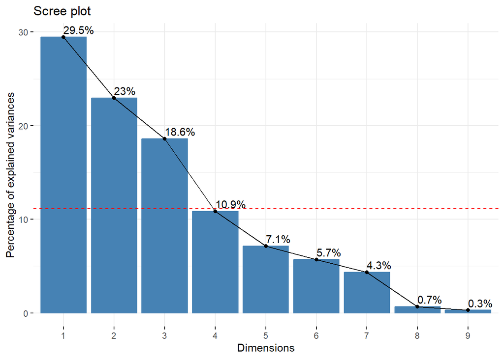

```r
library(FactoMineR)
library(factoextra)
res.pca = PCA(cerealsImp, scale.unit = TRUE, graph = FALSE, ncp = 10,
              quali.sup = which(descCere$tipo == "categorical"),
              quanti.sup = 13:15)
eig.val <- get_eigenvalue(res.pca)
VPmedio = 100 * (1/nrow(eig.val))
fviz_eig(res.pca, addlabels = TRUE) +
  geom_hline(yintercept=VPmedio, linetype=2, color="red")
```

```r
kable(eig.val[1:6,])
```

|  | eigenvalue | variance.percent | cumulative.variance.percent |
| --- | --- | --- | --- |
| Dim.1 | 2.6526191 | 29.473546 | 29.47355 |
| Dim.2 | 2.0657439 | 22.952710 | 52.42626 |
| Dim.3 | 1.6740530 | 18.600589 | 71.02685 |
| Dim.4 | 0.9771794 | 10.857548 | 81.88439 |
| Dim.5 | 0.6416395 | 7.129328 | 89.01372 |
| Dim.6 | 0.5130347 | 5.700386 | 94.71411 |

```r
K = 3
res.pca = PCA(cerealsImp, scale.unit = TRUE, graph = FALSE, ncp = K,
              quali.sup = which(descCere$tipo == "categorical"),
              quanti.sup = 13:15)
```

A partir del modelo con 10 componentes, seleccionamos el número de componentes principales (PC) más adecuado. Para ello, hemos generado el gráfico del codo, añadido la recta que indica la varianza explicada por cada PC si todas explicaran los mismo y la tabla con la varianza explicada por cada PC. Seleccionamos 3 PCs, que explican un 71% del total de variabilidad de los datos, porque cumplen tanto con el criterio del codo como con el de superar la “varianza media” explicada por PC.

*EJERCICIO 1*

*¿Qué pasaría si solamente quisiera centrar las variables sin escalarlas? ¿Podría hacerlo con la función PCA de FactoMineR? ¿Cómo debería proceder?*

# 4 Validación del modelo PCA

## 4.1 Detección de anómalos con T2-Hotelling

El estadístico $T^2$ de Hotelling nos permite identificar valores anómalos extremos, que podrían estar condicionando el modelo, es decir, la creación de las PCs. Este estadístico se calcula a partir de los scores. Por ello, visualizaremos también los gráficos de scores para las PCs seleccionadas, además del gráfico con los valores del $T^2$ tomando las 3 Ps e incluyendo los límites de confianza al 95% y 99%, en naranja y rojo, respectivamente.

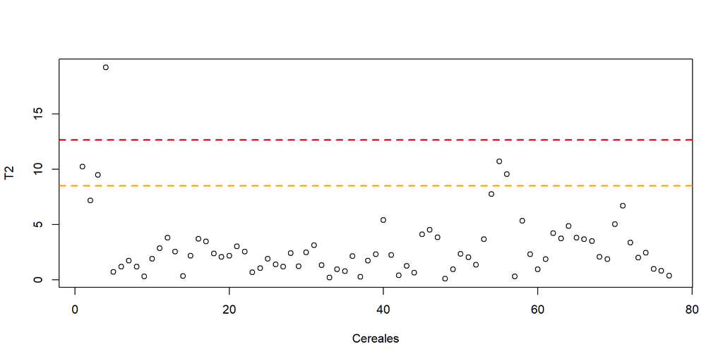

```r
# Gráfico T2 Hotelling
misScores = res.pca$ind$coord[,1:K]
miT2 = colSums(t(misScores**2)/eig.val[1:K,1])
I = nrow(cerealsImp)
F95 = K*(I**2 - 1)/(I*(I - K)) * qf(0.95, K, I-K)
F99 = K*(I**2 - 1)/(I*(I - K)) * qf(0.99, K, I-K)

plot(1:length(miT2), miT2, type = "p", xlab = "Cereales", ylab = "T2")
abline(h = F95, col = "orange", lty = 2, lwd = 2)
abline(h = F99, col = "red3", lty = 2, lwd = 2)
```

```r
anomalas = which(miT2 > F95)
anomalas
```

```
##                 100%_Bran                  All-Bran All-Bran_with_Extra_Fiber
##                         1                         3                         4
##               Puffed_Rice              Puffed_Wheat
##                        55                        56
```

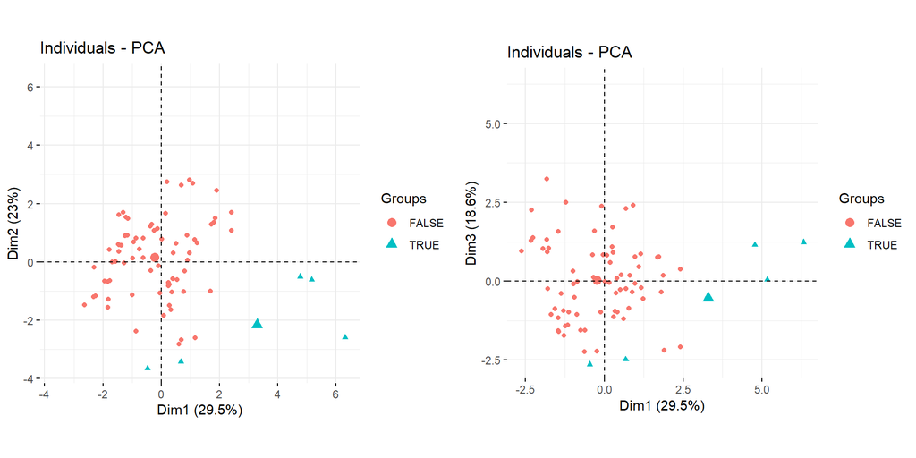

```r
# Score plots
library(grid)
library(gridExtra)


p1 = fviz_pca_ind(res.pca, axes = c(1,2), geom = c("point"),
                  habillage = factor(miT2 > F95)) +
  tune::coord_obs_pred()

p2 = fviz_pca_ind(res.pca, axes = c(1,3), geom = c("point"),
                  habillage = factor(miT2 > F95)) +
  tune::coord_obs_pred()


grid.arrange(p1,p2, nrow = 1)
```

**Conclusión:** Si nos fijamos en el límite del 95%, esperamos un 5% de falsos positivos, es decir 4 cereales, y hay 5 cereales anómalos que superan el límite. Por tanto, podríamos considerar excluir la marca de cereales con mayor valor de $T^2$, es decir, All-Bran_with_Extra_Fiber, y recalcular el modelo. La mantendremos en el modelo porque, dado que estamos estudiando el contenido nutricional de los cereales, es lógico que los cereales con alto contenido en fibra estén contribuyendo mucho al modelo y no deberíamos excluirlos ya que pueden ayudarnos a entender al valor del *rating*, como veremos más adelante.

*EJERCICIO 2*

*¿Cómo podríamos averiguar qué variable o variables son las “culpables”, es decir, han contribuido más a que All-Bran_with_Extra_Fiber haya resultado ser una observación anómala?*

*Solución EJERCICIO 2*

Si identificamos la observación anómala en el gráfico de scores, podemos utilizar los gráficos de loadings o los gráficos de variables (que se muestran más adelante) para entender qué variables contribuyen más a que esa observación haya resultado anómala. Otra forma de averiguarlo es mediante el gráfico de contribuciones a la $T^2$ de Hotelling que se muestra a continuación, y que ha sido programado a partir del artículo de Kourti y MacGregor (Journal of Quality Technology, 1996).

```r
contribT2 = function (X, scores, loadings, eigenval, observ, cutoff = 2) {
  # X is data matrix and must be centered (or centered and scaled if data were scaled)
  misScoresNorm = t(t(scores**2) / eigenval)
  misContrib = NULL
  for (oo in observ) {
    print(rownames(scores)[oo])
    print(scores[oo,])
    misPCs = which(as.numeric(misScoresNorm[oo,]) > cutoff)
    lacontri = sapply(misPCs, function (cc) (scores[oo,cc]/eigenval[cc])*loadings[,cc]*X[oo,])
    lacontri = rowSums((1*(sign(lacontri) == 1))*lacontri)
    misContrib = cbind(misContrib, lacontri)
  }
  colnames(misContrib) = rownames(misScoresNorm[observ,])
  return(misContrib)
}
```

La función anterior se ha programado para calcular las contribuciones a la $T^2$ de una o más observaciones anómalas. Aplicamos dicha función para calcular las contribuciones de nuestra observación anómala y las representamos gráficamente.

```r
# Recuperamos los datos utilizados en el modelo PCA, centrados y escalados
cerealsCE = cerealsImp[,descCere$tipo == "numerical"]
cerealsCE = cerealsCE[,setdiff(colnames(cerealsCE), c("rating", "weight", "cups"))]
cerealsCE = scale(cerealsCE, center = TRUE, scale = TRUE)
X = as.matrix(cerealsCE)
# Calculamos los loadings a partir de las coordenadas de las variables
# ya que la librería FactoMineR nos devuelve los loadings ponderados
# por la importancia de cada componente principal.
misLoadings = sweep(res.pca$var$coord, 2, sqrt(res.pca$eig[1:K,1]), FUN="/")
# Calculamos las contribuciones
mycontrisT2 = contribT2(X = X, scores = misScores, loadings = misLoadings,
                        eigenval = eig.val[1:K,1], observ = which.max(miT2),
                        cutoff = 2)
```

```
## [1] "All-Bran_with_Extra_Fiber"
##     Dim.1     Dim.2     Dim.3
##  6.317596 -2.593913  1.235453
```

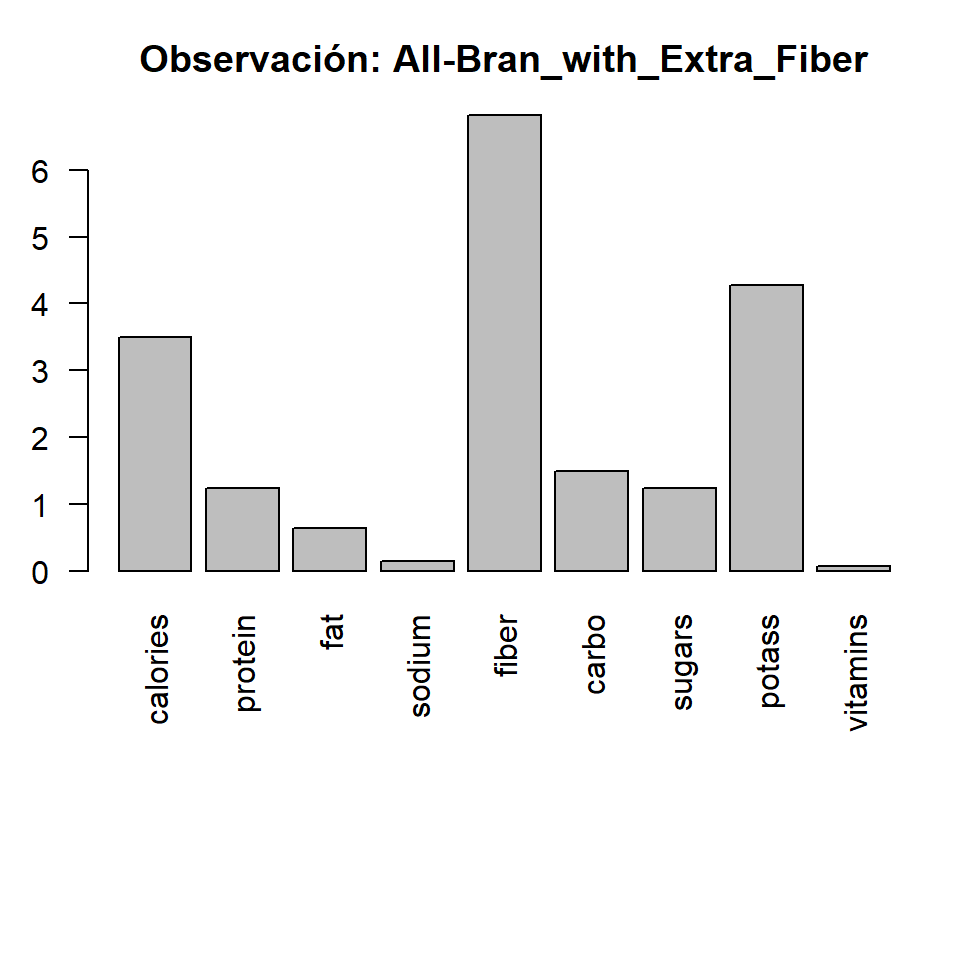

```r
par(mar = c(10,2.3,3,1))
barplot(mycontrisT2[,1],las=2, #cex.names = 0.5,
        main= paste0("Observación: ", rownames(cereals)[which.max(miT2)]))
```

El gráfico de contribuciones muestra que All-Bran_with_Extra_Fiber es anómalo debido a que tiene valores anormalmente altos (o bajos) en la variable *fiber* y un poco también en *potass*. Dado que el contenido en fibra puede ser relevante a la hora de entender cómo se ha otorgado el *rating* a los cereales, confirmamos que hacemos bien manteniendo esta observación en el modelo.

*EJERCICIO 3*

*Supongamos que el número de falsas alarmas fuera 2 para el límite de confianza del 95%. ¿Cómo seleccionaríamos los 3 cereales candidatos a ser excluidos del modelo PCA?*

## 4.2 Distancia al modelo (SCR)

Ahora estudiaremos la distancia al modelo PCA mediante la Suma de Cuadrados Residual (SCR), que nos ayudará a detectar los valores anómalos moderados, es decir, aquellas observaciones (cereales) que no están bien explicados por el modelo PCA. Recordemos que los anómalos severos son aquellos detectados con el gráfico $T^2$ de Hotelling pero que presentan una baja SCR.

Para ello, primero calcularemos la matriz de residuos y, a partir de ella, la SCR.

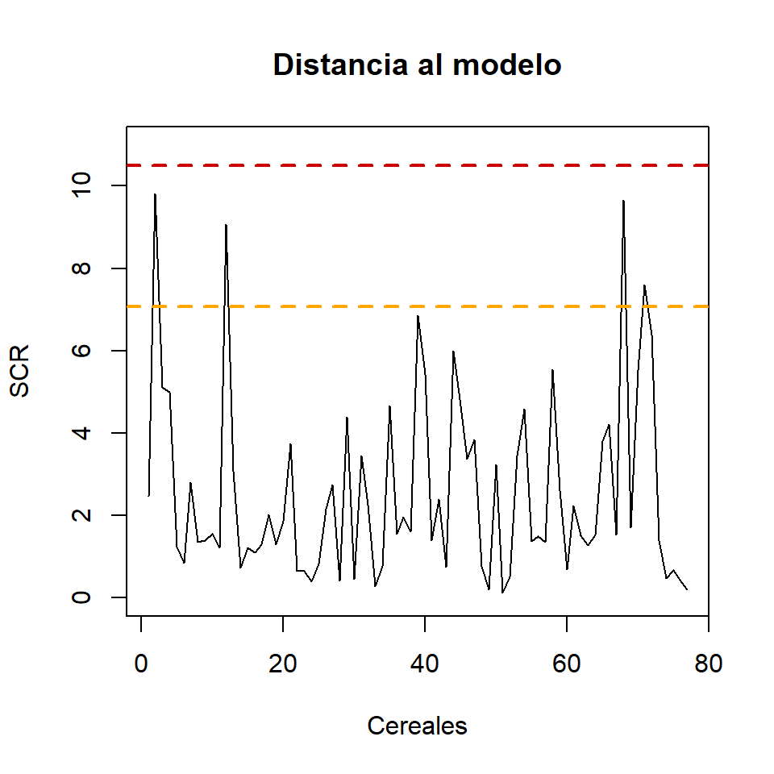

```r
myE = X - misScores %*% t(misLoadings)
mySCR = rowSums(myE^2)
plot(1:length(mySCR), mySCR, type = "l", main = "Distancia al modelo",
     ylab = "SCR", xlab = "Cereales", ylim = c(0,11))
g = var(mySCR)/(2*mean(mySCR))
h = (2*mean(mySCR)^2)/var(mySCR)
chi2lim = g*qchisq(0.95, df = h)
chi2lim99 = g*qchisq(0.99, df = h)
abline(h = chi2lim, col = "orange", lty = 2, lwd = 2)
abline(h = chi2lim99, col = "red3", lty = 2, lwd = 2)
```

**Conclusión:** En este caso, hay 4 cereales que se salen fuera del límite del 95%, y 0 fuera del límite del 99%.Dado que se podrían considerar falsas alarmas y tampoco distan en exceso del límite (menos de dos veces dicho límite), no descartaremos ninguna observación en este caso. Estas son las observaciones peor explicadas por el modelo: 100%_Natural_Bran, Cheerios, Special_K, Total_Raisin_Bran.

Aunque no nos planteamos excluir dichas observaciones, vamos a ver a modo de ejemplo, cómo averiguar qué características tienen estos cereales que los hacen diferentes a las tendencias generales resumidas por el modelo PCA. Para ello, vamos a crear una función que calcule las contribuciones de cada variable a la SCR de una observación concreta. Como ejemplo, generaremos el gráfico de contribuciones para los cereales “Special_K”.

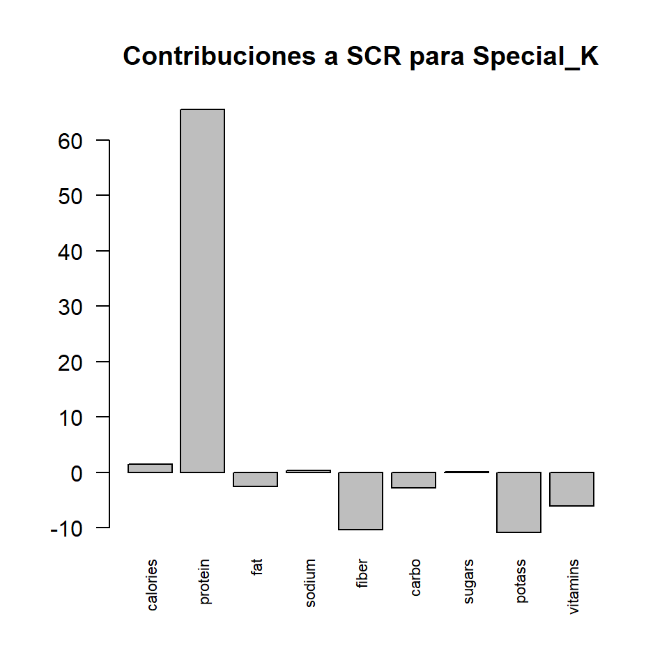

```r
## Función para calcular las contribuciones a la SCR
ContriSCR = function(E, SCR) {
  # E es la matriz de residuos del modelo
  # SCR es la suma de cuadrados residual
  contribucion = NULL
  for (j in 1:length(SCR)){
    eind<-E[j,]
    signo<-sign(eind)
    contri<-(signo*(eind^2)/SCR[j])*100
    contribucion<-rbind(contribucion,contri)
  }
  rownames(contribucion) = rownames(E)
  return(contribucion)
}
## Calculamos las contribuciones de todas las observaciones
mycontris = ContriSCR(E = myE, SCR = mySCR)
## Gráfico para Special_K
barplot(mycontris["Special_K",],las=2, cex.names = 0.7,
        main=c('Contribuciones a SCR para Special_K'))
```

Como podemos observar, los cereales “Special_K” tienen un contenido “anormalmente” elevado en proteínas, lo cual les hace tener un patrón diferente a los descritos por el modelo PCA.

*EJERCICIO 4*

*¿Se puede considerar a All-Bran_with_Extra_Fiber como un valor anómalo severo? En caso afirmativo, ¿implica que debo eliminarlo necesariamente del modelo PCA?*

# 5 Interpretación del modelo PCA

Una vez excluidos, si es el caso, los valores anómalos y recalculado el modelo PCA sin ellos, procederemos a interpretarlo.

## 5.1 Gráficos de variables

Empezaremos, por ejemplo, por el gráfico de variables. Como se ha dicho anteriormente, la librería FactoMineR no representa el gráfico de *loadings*, sino un gráfico con los loadings corregidos por la importancia de cada componente $k$ ($\sqrt{\lambda_k}$).

Dado que hemos seleccionado anteriormente 3 PCS, debemos asegurarnos de que las 3 se representan en nuestros gráficos. Aquí, por ejemplo, hemos optado por representar la 1 frente a la 2 y la 1 frente a la 3:

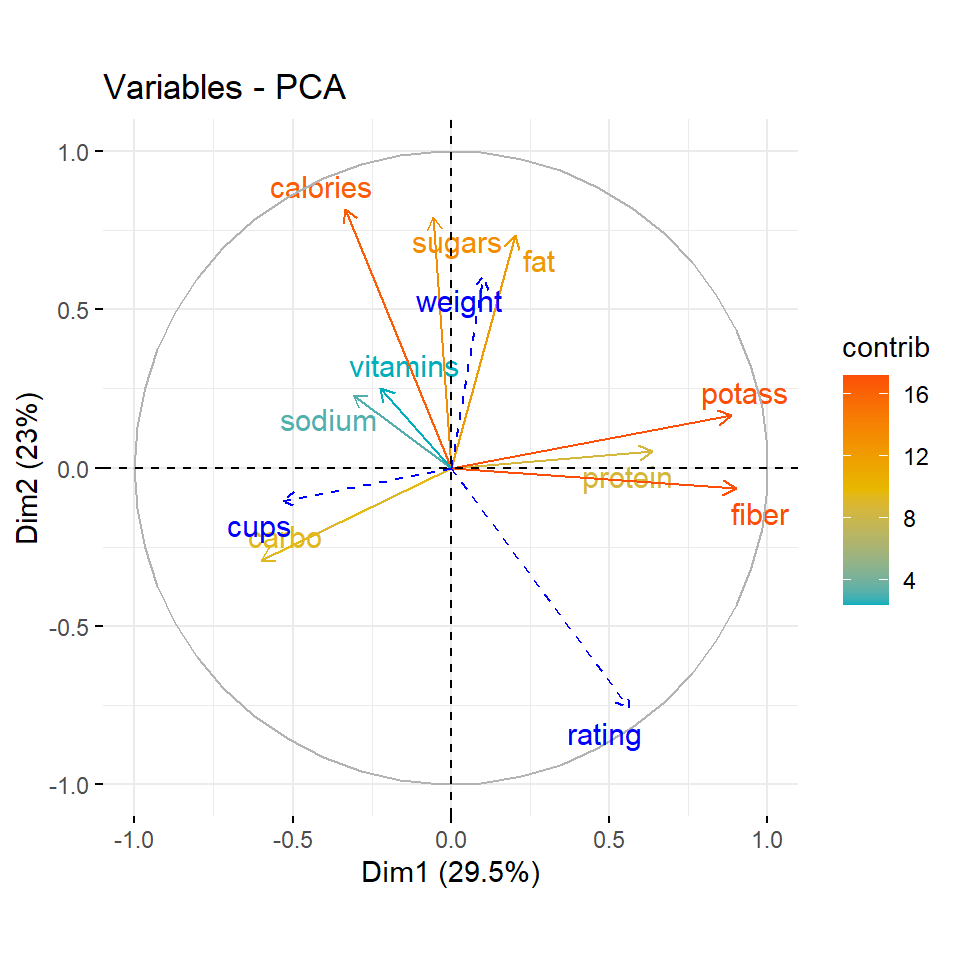

```r
fviz_pca_var(res.pca, axes = c(1,2), repel = TRUE, col.var = "contrib",
             gradient.cols = c("#00AFBB", "#E7B800", "#FC4E07"))
```

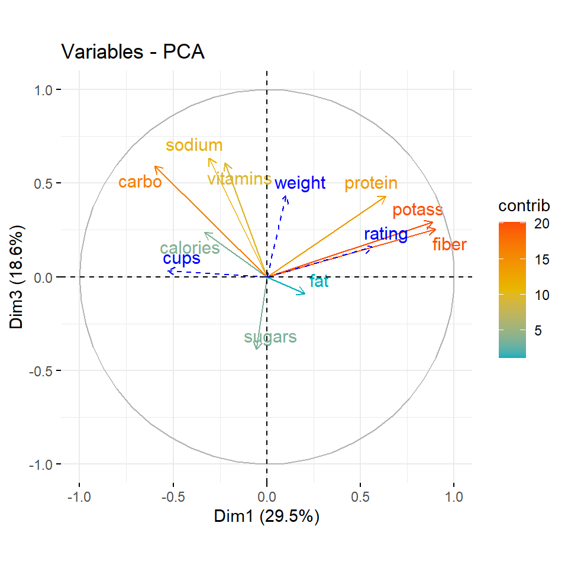

```r
fviz_pca_var(res.pca, axes = c(1,3), repel = TRUE, col.var = "contrib",
             gradient.cols = c("#00AFBB", "#E7B800", "#FC4E07"))
```

En los gráficos anteriores, las variables han sido coloreadas por su contribución a las PCs representadas en el gráfico. En color azul se muestran las variables auxiliares numéricas, que no han sido utilizados para la obtención matemática del modelo PCA, pero que se han proyectado sobre el nuevo espacio de componentes.

Las variables que más contribuyen a la PC1 son la fibra y el potasio, que además son variables bastante correlacionadas (positivamente). En menor medida queda explicada esta PC por las proteínas y los carbohidratos. Los carbohidratos y el potasio parecen estar negativamente correlacionadas. En cambio, la PC2 está explicada por componentes nutricionales “poco sanos” como grasas, azúcares y calorías, y estas dos últimas variables están bastante correlacionadas entre sí. Si nos fijamos en el rating, vemos que está inversamente relacionado con las calorías.

El segundo gráfico, parece confirmar la correlación positiva entre fibra y potasio, y también de estas dos variables con el rating.

A continuación, generamos gráficos de dispersión para comprobar las hipótesis sobre relaciones entre variables sugeridas por el PCA:

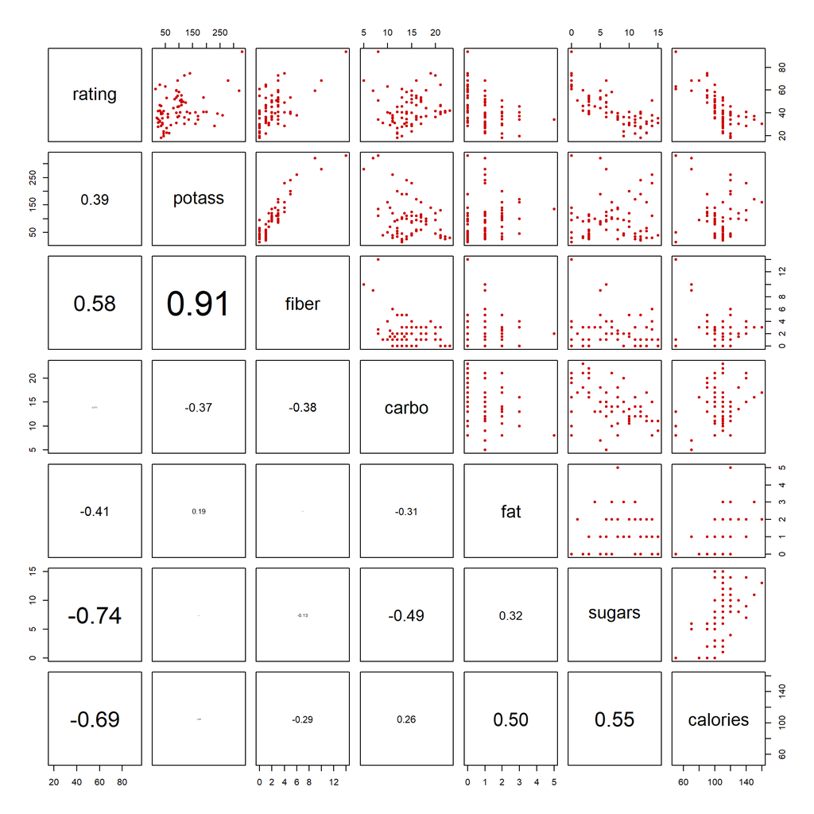

```r
panel.cor <- function(x, y, digits = 2, prefix = "", cex.cor, ...)
{
    par(usr = c(0, 1, 0, 1))
    r <- cor(x, y)
    txt <- format(c(r, 0.123456789), digits = digits)[1]
    txt <- paste0(prefix, txt)
    if(missing(cex.cor)) cex.cor <- 0.8/strwidth(txt)
    text(0.5, 0.5, txt, cex = cex.cor * abs(r))
}
pairs(cerealsImp[,c("rating", "potass", "fiber", "carbo", "fat", "sugars", "calories")],
      lower.panel = panel.cor, pch = 20, col = "red3")
```

A la vista de estos gráficos y correlaciones, ¿se podrían considerar ciertas las afirmaciones que hemos hecho al interpretar el gráfico de variables del PCA?

**NOTA IMPORTANTE:** No es obligatorio hacer siempre estas comprobaciones. Las hemos hecho para ayudar a entender mejor la interpretación del PCA. No obstante, nunca está de más generar aquellos gráficos que consideréis necesarios para ilustrar las conclusiones extraídas del PCA acerca de la relación entre variables y corroborarlas.

En el caso de que no se pueda visualizar bien en los gráficos anteriores la importancia o contribución de cada variable a cada componente, podemos usar de forma complementaria un gráfico auxiliar como el siguiente para la PC que deseemos representar (en este ejemplo se ha elegido la primera PC):

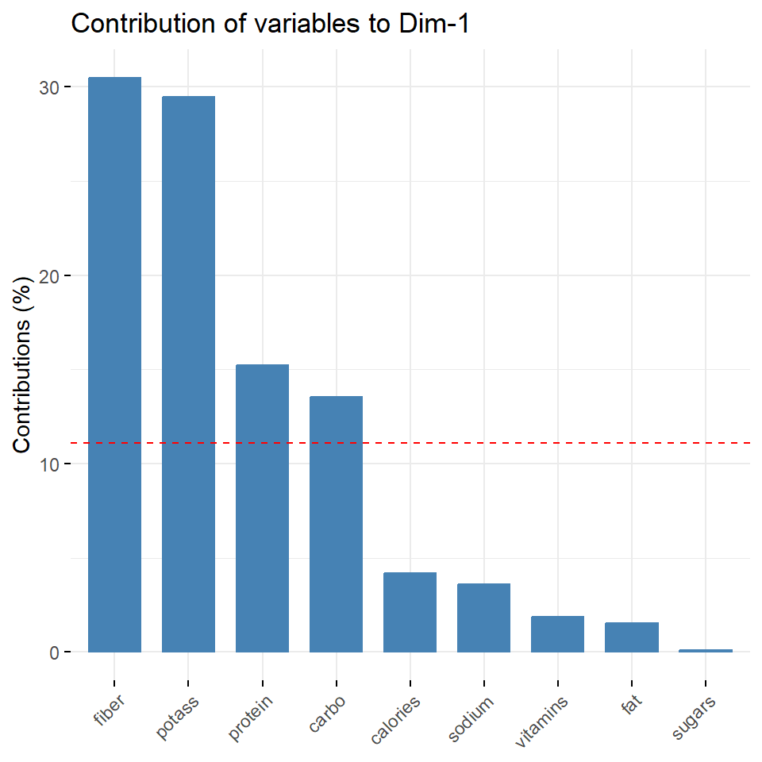

```r
fviz_contrib(res.pca, choice = "var", axes = 1)
```

**IMPORTANTE:** Estos gráficos de barras nunca pueden sustituir a los gráficos de variables (los primeros que hemos generado en esta sección), ya que no nos permiten estudiar las relaciones entre variables.

Otra opción, es representar en los gráficos de variables, solo aquellas variables con mayor contribución a las PCs, seleccionando para ello los argumentos apropiados.

*EJERCICIO 5*

*Genera el gráfico de LOADINGS para las dos primeras componentes principales y compáralo con el gráfico de variables obtenido anteriormente mediante FactoMineR.*

*EJERCICIO 6*

*Calcula el porcentaje de variabilidad de cada variable $k$ que queda explicado por el modelo PCA ($R^2_k(cum)$) obtenido y represéntalo en un gráfico. ¿Qué variable está mejor explicada por el modelo PCA?*

## 5.2 Gráficos de observaciones: Score plot

En esta sección, mostraremos solo los gráficos para las 2 primeras componentes principales. Se tienen que analizar también la PC 3, de forma análoga a como se hizo para las variables. Queda como ejercicio, pues, explorar e interpretar el gráfico que incluya la PC3.

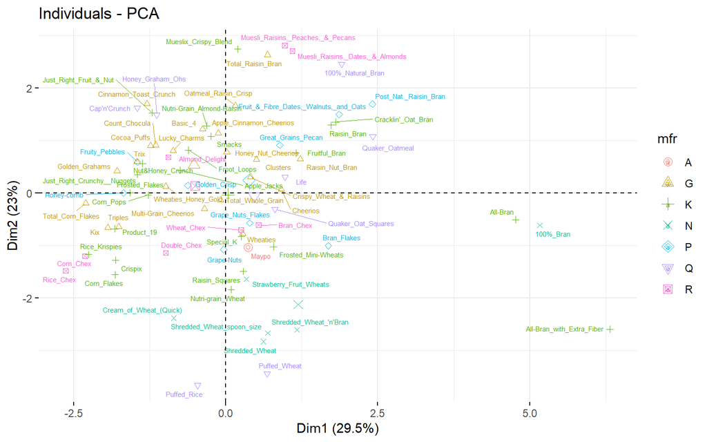

```r
# Gráfico de scores para todos los cereales coloreados por fabricante
fviz_pca_ind(res.pca, axes = c(1,2), geom = c("point", "text"),
             habillage = "mfr", repel = TRUE, labelsize = 2)
```

Observamos que la principal agrupación de los cereales no es por el fabricante, sino que dicha agrupación obedece a algunas variables nutricionales. Sin embargo, una vez identificados los cereales con, por ejemplo, alto o bajo contenido en azúcares, grasas y calorías, vemos que sí que tienden a estar juntos los cereales del mismo fabricante. Lo mismo sucede si relacionamos los cereales con otras variables nutricionales. Vemos también cereales con valores positivos muy extremos en la PC1. Se trata de cereales un tanto “anómalos” por su alto contenido en fibra y potasio. En concreto, parece que All-Bran-with-Extra-Fiber será el tipo de cereal con mayor rating.

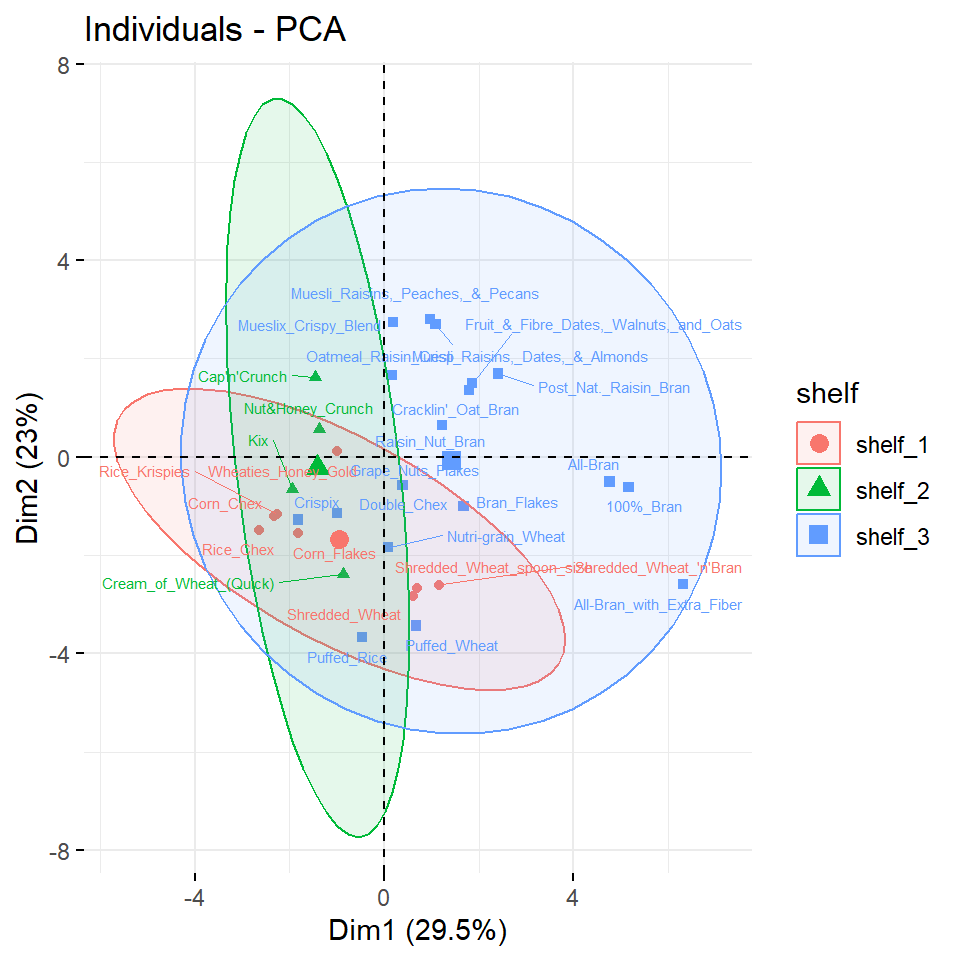

```r
# Gráficos de scores para los 30 cereales mejor representados en las PCs 1 y 2
# coloreados por la estantería y con la elipse de confianza para cada estantería
fviz_pca_ind(res.pca, axes = c(1,2), geom = c("point", "text"), repel = TRUE, labelsize = 2,
             select.ind = list("cos2"=30), habillage = "shelf", addEllipses = TRUE)
```

En este segundo gráfico, no podemos observar una agrupación de los cereales en función de la estantería del supermercado en la que son colocados, aunque sí que parece que los cereales con más contenido en fibra, potasio y proteínas (y, por tanto, más rating), tienden a ser colocados en la estantería más alta (la 3).

## 5.3 Biplot

En ocasiones es útil representar en el mismo gráfico las variables y las observaciones, para mejorar la interpretación. No obstante, hay que afinar en la forma de representar estos gráficos porque si tenemos muchas observaciones y/o variables es posible que no sea la mejor opción porque quizás no se visualice bien lo que queremos mostrar.

En este caso, no mostraremos el nombre de los cereales, solo el de las variables. Colorearemos los cereales según el fabricante, por ejemplo.

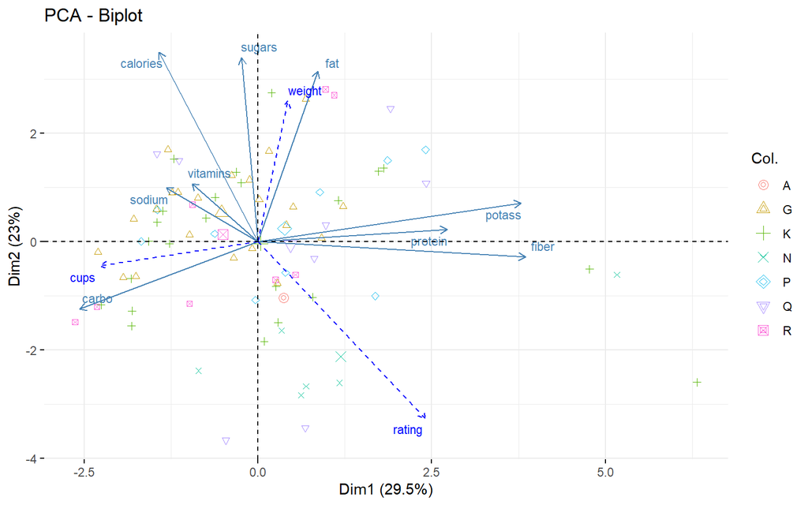

```r
fviz_pca_biplot(res.pca, axes = c(1,2), labelsize = 3,
                label = "var", repel = TRUE,
                col.ind = cerealsImp$mfr)
```

**NOTA IMPORTANTE**

En esta práctica guiada se han mostrado distintas gráficas generadas a partir del modelo PCA y con distintas opciones de representación, coloreado, etiquetado, etc. No todas las gráficas son igual de explicativas o útiles en todos los análisis PCA. Dependiendo de las características de la BBDD a analizar, se deben elegir las gráficas y opciones más apropiadas, que ayuden a interpretar y visualizar mejor los resultados.